# Business Potential for Macrame Based Products on Etsy

## Clustering with KMeans

Clustering was the final part of this as I wanted to see if there were some relation (that I was missing) between good sellers and their prices and profits.

I tried **KMeans** using **scikit learn** and give me pretty good results on the narrowed sellers dataset (no so good on the complete one).

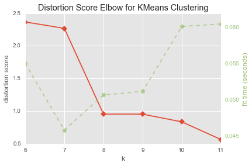

KMeans elbow method

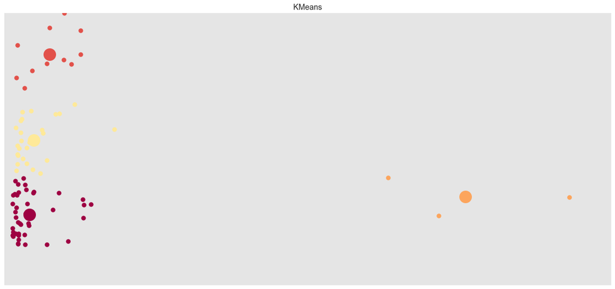

Clustering with KMeans

# Discussion

There seems to be a great deal of opportunity in this niche and if you want to get in you should adopt an strategy that will keep you safe so I recommend to try out decoration products, specially **wall hangers**, and perhaps some unusual, but cool, materials, in this way you explore the benefits of this two, most profitable, sub-niches. Jewerly is only good when you add some precious rocks and for this addition you can charge more. There is no strong correlation between quantities and profits in the case of jewelry, so don’t try that. On the other hand there are sellers doing pretty good listing few thing but at a high price (wall hangers), for example one seller is making about $418904.00/year by selling wall hangers exclusively.

Ofcourse there is a lot of work, from this top sellers, that we cannot see here and an important factor will be from you to find out how to get noticed (maybe using social networks or something like that).

Keep watching the trends to get onboard on time and to noticed the declined of this one.

# Conclusion

No way this has end in here, there are a lot of corrections to be made and some more information to gather but overall this is a good start to begin to understand the opportunities and difficulties to become a merchant on a crawded ecommerce platform.